# Step 1: Connect to SQLite Database

```python
import sqlite3
import pandas as pd
import matplotlib.pyplot as plt
import seaborn as sns

import warnings
warnings.filterwarnings("ignore")

conn = sqlite3.connect("mydatabase.db")

csv_files = {
    "orders": "orders.csv",
    "staffs": "staffs.csv",
    "customers": "customers.csv",
    "stores": "stores.csv",
    "order_items": "order_items.csv"
}

for table_name, csv_file in csv_files.items():
    df = pd.read_csv(csv_file)
    df.to_sql(table_name, conn, if_exists='replace', index=False)
```

```python
cursor = conn.cursor()
cursor.execute("SELECT name FROM sqlite_master WHERE type='table';")
print(cursor.fetchall())
```

```
[('orders',), ('staffs',), ('customers',), ('stores',), ('order_items',)]
```

```python
# A function to display any table by putting its name into the function
def view_table(name):
    df = pd.read_sql_query(f"SELECT * FROM {name} LIMIT 5", conn)
    display(df)

view_table("orders")
```

|  | order_id | customer_id | order_status | order_date | required_date | shipped_date | store_id | staff_id |
| --- | --- | --- | --- | --- | --- | --- | --- | --- |
| 0 | 1 | 259 | 4 | 2016-01-01 | 2016-01-03 | 2016-01-03 | 1 | 2 |
| 1 | 2 | 1212 | 4 | 2016-01-01 | 2016-01-04 | 2016-01-03 | 2 | 6 |
| 2 | 3 | 523 | 4 | 2016-01-02 | 2016-01-05 | 2016-01-03 | 2 | 7 |
| 3 | 4 | 175 | 4 | 2016-01-03 | 2016-01-04 | 2016-01-05 | 1 | 3 |
| 4 | 5 | 1324 | 4 | 2016-01-03 | 2016-01-06 | 2016-01-06 | 2 | 6 |

# Step 2: Database Keys and Relationships

- **Primary Keys:**
  - `customers`: `customer_id`
  - `orders`: `order_id`
  - `order_items`: composite key of (`order_id`, `item_id`) or `item_id` if unique
  - `staff`: `staff_id`
  - `stores`: `store_id`
- **Foreign Keys:**
  - `orders.customer_id` → `customers.customer_id`
  - `orders.store_id` → `stores.store_id`
  - `orders.staff_id` → `staff.staff_id`
  - `order_items.order_id` → `orders.order_id`
  - `order_items.product_id` → (assuming a `products` table, not listed here)
  - `staff.store_id` → `stores.store_id`
  - `staff.manager_id` → `staff.staff_id` (self-referential for manager)
- **Relationships:**
  - One **customer** can have many **orders** (1-to-many)
  - One **order** can have many **order_items** (1-to-many)
  - One **store** has many **staff** members (1-to-many)
  - One **staff** member can manage multiple other **staff** members (1-to-many self relationship)
  - Each **order** is created by one **staff** and belongs to one **store**

# Step 3: Writing SQL Queries

```python
# Defining a function to use to easily run SQL queries
def run_query(sql_query, conn):
    df = pd.read_sql_query(sql_query, conn)
    display(df)
    return df
```

```python
# Joining orders + customers tables using an inner join

query1 = """
SELECT
    orders.order_id,
    orders.order_date,
    customers.first_name,
    customers.last_name
FROM orders
JOIN customers ON orders.customer_id = customers.customer_id
LIMIT 10;
"""

df1 = run_query(query1, conn)
```

|  | order_id | order_date | first_name | last_name |
| --- | --- | --- | --- | --- |
| 0 | 1 | 2016-01-01 | Johnathan | Velazquez |
| 1 | 2 | 2016-01-01 | Jaqueline | Cummings |
| 2 | 3 | 2016-01-02 | Joshua | Robertson |
| 3 | 4 | 2016-01-03 | Nova | Hess |
| 4 | 5 | 2016-01-03 | Arla | Ellis |
| 5 | 6 | 2016-01-04 | Sharyn | Hopkins |
| 6 | 7 | 2016-01-04 | Laureen | Paul |
| 7 | 8 | 2016-01-04 | Leslie | Higgins |
| 8 | 9 | 2016-01-05 | Neil | Mccall |
| 9 | 10 | 2016-01-05 | Alane | Munoz |

```python
# Joining staffs + stores tables using inner join

query2 = """
SELECT
    staffs.first_name,
    staffs.last_name,
    stores.store_name
FROM staffs
JOIN stores ON staffs.store_id = stores.store_id
LIMIT 10;
"""

df2 = run_query(query2, conn)
```

|  | first_name | last_name | store_name |
| --- | --- | --- | --- |
| 0 | Fabiola | Jackson | Santa Cruz Bikes |
| 1 | Mireya | Copeland | Santa Cruz Bikes |
| 2 | Genna | Serrano | Santa Cruz Bikes |
| 3 | Virgie | Wiggins | Santa Cruz Bikes |
| 4 | Jannette | David | Baldwin Bikes |
| 5 | Marcelene | Boyer | Baldwin Bikes |
| 6 | Venita | Daniel | Baldwin Bikes |
| 7 | Kali | Vargas | Rowlett Bikes |
| 8 | Layla | Terrell | Rowlett Bikes |
| 9 | Bernardine | Houston | Rowlett Bikes |

```python
# Total revenue per order

query3 = """
SELECT
    order_id,
    SUM(quantity * list_price * (1 - discount)) AS total_revenue
FROM order_items
GROUP BY order_id
LIMIT 10;
"""

df3 = run_query(query3, conn)
```

|  | order_id | total_revenue |
| --- | --- | --- |
| 0 | 1 | 10231.0464 |
| 1 | 2 | 1697.9717 |
| 2 | 3 | 1519.9810 |
| 3 | 4 | 1349.9820 |
| 4 | 5 | 3900.0607 |
| 5 | 6 | 9442.5048 |
| 6 | 7 | 2165.0817 |
| 7 | 8 | 1372.4719 |
| 8 | 9 | 7199.9820 |
| 9 | 10 | 242.9910 |

```python
# Total revenue per customer

query4 = """
SELECT
    customers.customer_id,
    customers.first_name,
    customers.last_name,
    SUM(order_items.quantity * order_items.list_price * (1 - order_items.discount)) AS total_spent
FROM customers
JOIN orders ON customers.customer_id = orders.customer_id
JOIN order_items ON orders.order_id = order_items.order_id
GROUP BY customers.customer_id, customers.first_name, customers.last_name
ORDER BY total_spent DESC
LIMIT 10;
"""

df4 = run_query(query4, conn)
```

|  | customer_id | first_name | last_name | total_spent |
| --- | --- | --- | --- | --- |
| 0 | 94 | Sharyn | Hopkins | 34807.9392 |
| 1 | 10 | Pamelia | Newman | 33634.2604 |
| 2 | 75 | Abby | Gamble | 32803.0062 |
| 3 | 6 | Lyndsey | Bean | 32675.0725 |
| 4 | 16 | Emmitt | Sanchez | 31925.8857 |
| 5 | 73 | Melanie | Hayes | 31913.6902 |
| 6 | 1 | Debra | Burks | 27888.1834 |
| 7 | 61 | Elinore | Aguilar | 25636.4531 |
| 8 | 93 | Corrina | Sawyer | 25612.7021 |
| 9 | 122 | Shena | Carter | 24890.6244 |

```python
# List the first and last names of customers and the dates of the orders they placed.

query5 = """
SELECT
    customers.first_name,
    customers.last_name,
    orders.order_date
FROM customers
JOIN orders ON customers.customer_id = orders.customer_id
LIMIT 10;
"""

df5 = run_query(query5, conn)
```

|  | first_name | last_name | order_date |
| --- | --- | --- | --- |
| 0 | Debra | Burks | 2016-12-09 |
| 1 | Debra | Burks | 2018-04-18 |
| 2 | Debra | Burks | 2018-11-18 |
| 3 | Kasha | Todd | 2017-02-05 |
| 4 | Kasha | Todd | 2017-08-21 |
| 5 | Kasha | Todd | 2018-04-09 |
| 6 | Tameka | Fisher | 2018-03-27 |
| 7 | Tameka | Fisher | 2018-04-06 |
| 8 | Tameka | Fisher | 2018-10-21 |
| 9 | Daryl | Spence | 2017-02-07 |

```python
# Where the staff work and their managers

query6 = """
SELECT
    s.first_name AS staff_first,
    s.last_name AS staff_last,
    st.store_name,
    m.first_name AS manager_first,
    m.last_name AS manager_last
FROM staffs AS s
JOIN stores AS st ON s.store_id = st.store_id
JOIN staffs AS m ON s.manager_id = m.staff_id
LIMIT 10;
"""

df6 = run_query(query6, conn)
```

|  | staff_first | staff_last | store_name | manager_first | manager_last |
| --- | --- | --- | --- | --- | --- |
| 0 | Mireya | Copeland | Santa Cruz Bikes | Fabiola | Jackson |
| 1 | Genna | Serrano | Santa Cruz Bikes | Mireya | Copeland |
| 2 | Virgie | Wiggins | Santa Cruz Bikes | Mireya | Copeland |
| 3 | Jannette | David | Baldwin Bikes | Fabiola | Jackson |
| 4 | Marcelene | Boyer | Baldwin Bikes | Jannette | David |
| 5 | Venita | Daniel | Baldwin Bikes | Jannette | David |
| 6 | Kali | Vargas | Rowlett Bikes | Fabiola | Jackson |
| 7 | Layla | Terrell | Rowlett Bikes | Venita | Daniel |
| 8 | Bernardine | Houston | Rowlett Bikes | Venita | Daniel |

# Step 3: Visualize Data

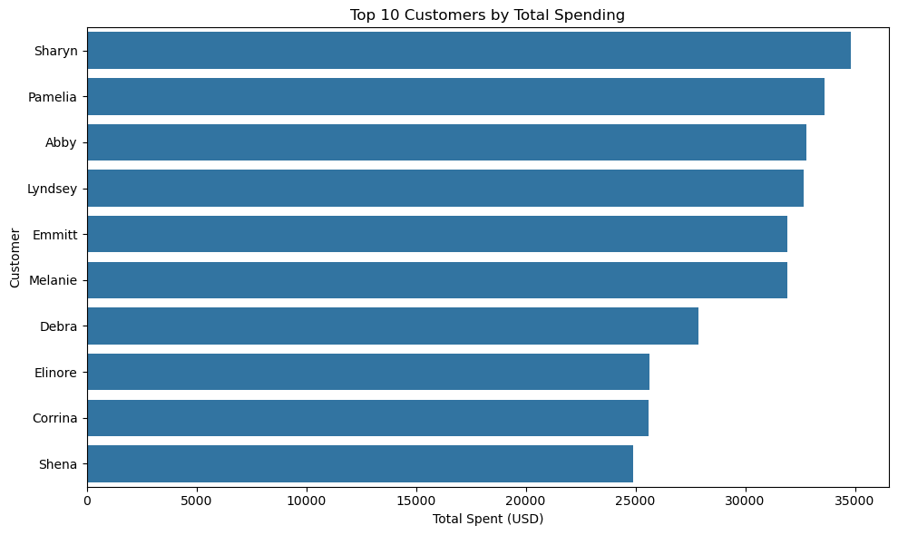

```python
# Top-Spending Customers (from query4)

plt.figure(figsize=(10, 6))
sns.barplot(x='total_spent', y='first_name', data=df4)
plt.title('Top 10 Customers by Total Spending')
plt.xlabel('Total Spent (USD)')
plt.ylabel('Customer')
plt.tight_layout()
plt.show()
```

### 💸 Top Spending Customers – Insights

- The top customer, **Sharyn Hopkins**, spent approximately **$34.8K**, making her one of the store’s most valuable clients.
- All top 10 customers spent **over $24K**, indicating a clear group of **high-value customers**.
- These insights could support targeted marketing efforts or loyalty programs to retain and reward top spenders.

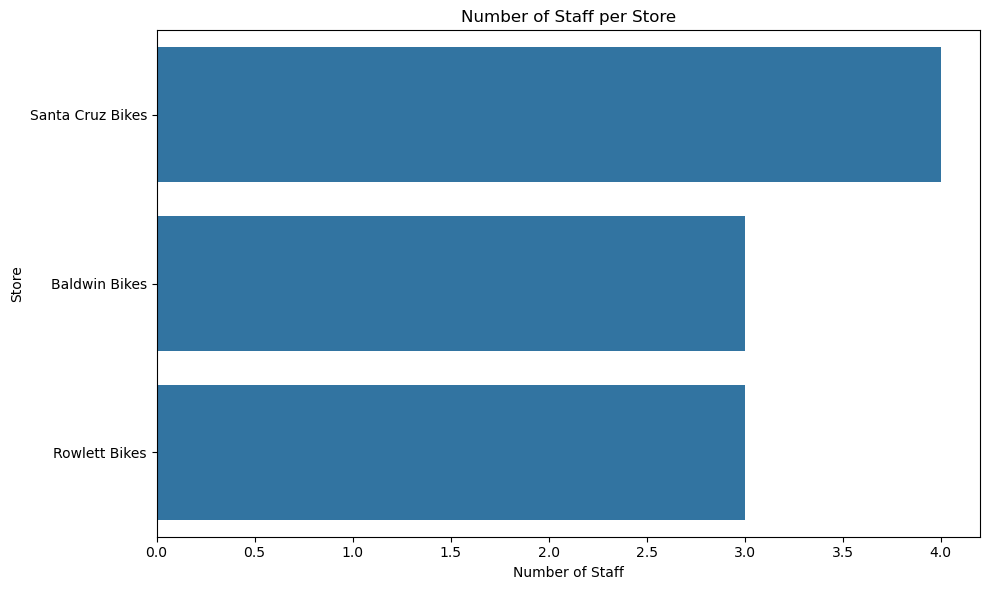

```python
# Staff Count per Store (from query2)

plt.figure(figsize=(10, 6))
sns.countplot(data=df2, y='store_name', order=df2['store_name'].value_counts().index)
plt.title('Number of Staff per Store')
plt.xlabel('Number of Staff')
plt.ylabel('Store')
plt.tight_layout()
plt.show()
```

### 🏬 Staff Distribution Across Stores – Insights

- The **Santa Cruz Bikes** store has a larger concentration of staff, with the top 4 employees all working there. This may indicate a bigger or busier location.
- Both **Baldwin Bikes** and **Rowlett Bikes** have multiple staff members, suggesting they are also active store locations but possibly smaller or less staffed than Santa Cruz.
- Understanding staff distribution helps identify where the workforce is concentrated and can inform decisions on resource allocation or management focus.

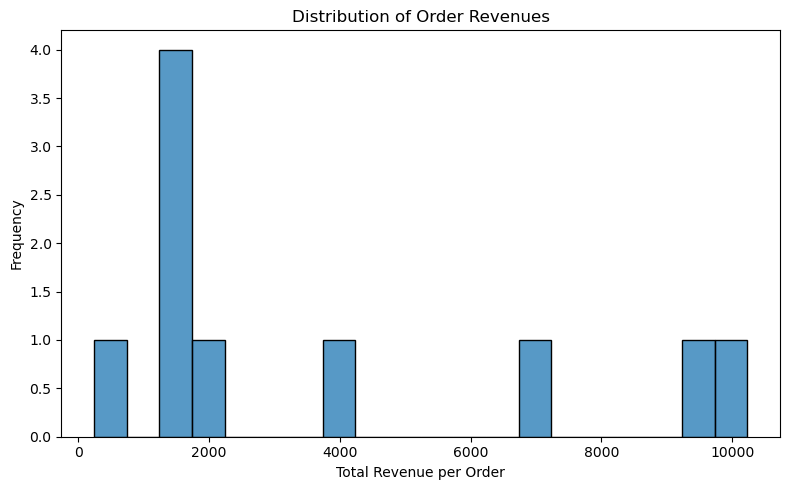

```python
# Order Revenue Distribution (from query3)

plt.figure(figsize=(8, 5))
sns.histplot(df3['total_revenue'], bins=20)
plt.title('Distribution of Order Revenues')
plt.xlabel('Total Revenue per Order')
plt.ylabel('Frequency')
plt.tight_layout()
plt.show()
```